# Practical Machine Learning Class Project

David Li

October 21, 2015

## Background and Introduction

This is a homework assignment of Coursera’s Practical Machine Learning from Johns Hopkins University. Here is the introduction and requirement of the exercise:

Using devices such as Jawbone Up, Nike FuelBand, and Fitbit it is now possible to collect a large amount of data about personal activity relatively inexpensively. These type of devices are part of the quantified self movement – a group of enthusiasts who take measurements about themselves regularly to improve their health, to find patterns in their behavior, or because they are tech geeks. One thing that people regularly do is quantify how much of a particular activity they do, but they rarely quantify how well they do it. In this project, your goal will be to use data from accelerometers on the belt, forearm, arm, and dumbell of 6 participants. They were asked to perform barbell lifts correctly and incorrectly in 5 different ways. More information is available from the website here: http://groupware.les.inf.puc-rio.br/har (see the section on the Weight Lifting Exercise Dataset).

The goal of my project is to predict the manner in which they did the exercise. This is the “classe” variable in the training set. I need to create a report describing how I built my model, how I used cross validation, what I think the expected out of sample error is, and why I made the choices I did. And I will also use my prediction model to predict 20 different test cases.

## Data Source

The training data for this project are available here:

https://d396qusza40orc.cloudfront.net/predmachlearn/pml-training.csv

The test data are available here:

https://d396qusza40orc.cloudfront.net/predmachlearn/pml-testing.csv

The data for this project comes from this original source: http://groupware.les.inf.puc-rio.br/har. If you use the document you create for this class for any purpose please cite them as they have been very generous in allowing their data to be used for this kind of assignment.

## Data Loading & Pre-processing

### Data Loading

Please Note that I download the data first from the links referenced above to my computer and upload the files into R (using RStudio).

```r
library("caret")
library("rpart")
library("randomForest")
library("rattle")

data.train <- read.csv("pml-training.csv", na.strings = c("","NA", "#DIV/0!"))
data.testcase <- read.csv("pml-testing.csv", na.strings = c("","NA", "#DIV/0!"))
dim(data.train)
```

```
## [1] 19622   160
```

```r
str(data.train)
```

```
## 'data.frame':    19622 obs. of  160 variables:
##  $ X                       : int  1 2 3 4 5 6 7 8 9 10 ...
##  $ user_name               : Factor w/ 6 levels "adelmo","carlitos",..: 2 2 2 2 2 2 2 2 2 2 ...
##  $ raw_timestamp_part_1    : int  1323084231 1323084231 1323084231 1323084232 1323084232 1323084232 1323084232 1323084232 1323084232 1323084232 ...
##  $ raw_timestamp_part_2    : int  788290 808298 820366 120339 196328 304277 368296 440390 484323 484434 ...
##  $ cvtd_timestamp          : Factor w/ 20 levels "02/12/2011 13:32",..: 9 9 9 9 9 9 9 9 9 9 ...
##  $ new_window              : Factor w/ 2 levels "no","yes": 1 1 1 1 1 1 1 1 1 1 ...
##  $ num_window              : int  11 11 11 12 12 12 12 12 12 12 ...
##  $ roll_belt               : num  1.41 1.41 1.42 1.48 1.48 1.45 1.42 1.42 1.43 1.45 ...
##  $ pitch_belt              : num  8.07 8.07 8.07 8.05 8.07 8.06 8.09 8.13 8.16 8.17 ...
##  $ yaw_belt                : num  -94.4 -94.4 -94.4 -94.4 -94.4 -94.4 -94.4 -94.4 -94.4 -94.4 ...
##  $ total_accel_belt        : int  3 3 3 3 3 3 3 3 3 3 ...
##  $ kurtosis_roll_belt      : num  NA NA NA NA NA NA NA NA NA NA ...
##  $ kurtosis_picth_belt     : num  NA NA NA NA NA NA NA NA NA NA ...
##  $ kurtosis_yaw_belt       : logi  NA NA NA NA NA NA ...
```

[output cut: 86 more lines]

### Data Pre-processing

Some of variablea in the data set only have a single unique value or have only a handful of unique values that occur with very low frequencies. I built a variable deduction function to exclude those variable of which non-NA value less than 10% of the total observations. After the variable deduction, the final variables become 53 including “classe”.

```r
isExcludeVar <- sapply(data.train, function (x) {sum(!is.na(x))/length(x) < 0.10})
data.train <- data.train[, !isExcludeVar]
data.train <- data.train[, -(1:7)]
dim(data.train)
```

```
## [1] 19622    53
```

```r
str(data.train)
```

```
## 'data.frame':    19622 obs. of  53 variables:
##  $ roll_belt           : num  1.41 1.41 1.42 1.48 1.48 1.45 1.42 1.42 1.43 1.45 ...
##  $ pitch_belt          : num  8.07 8.07 8.07 8.05 8.07 8.06 8.09 8.13 8.16 8.17 ...
##  $ yaw_belt            : num  -94.4 -94.4 -94.4 -94.4 -94.4 -94.4 -94.4 -94.4 -94.4 -94.4 ...
##  $ total_accel_belt    : int  3 3 3 3 3 3 3 3 3 3 ...
##  $ gyros_belt_x        : num  0 0.02 0 0.02 0.02 0.02 0.02 0.02 0.02 0.03 ...
##  $ gyros_belt_y        : num  0 0 0 0 0.02 0 0 0 0 0 ...
##  $ gyros_belt_z        : num  -0.02 -0.02 -0.02 -0.03 -0.02 -0.02 -0.02 -0.02 -0.02 0 ...
##  $ accel_belt_x        : int  -21 -22 -20 -22 -21 -21 -22 -22 -20 -21 ...
##  $ accel_belt_y        : int  4 4 5 3 2 4 3 4 2 4 ...
##  $ accel_belt_z        : int  22 22 23 21 24 21 21 21 24 22 ...
##  $ magnet_belt_x       : int  -3 -7 -2 -6 -6 0 -4 -2 1 -3 ...
##  $ magnet_belt_y       : int  599 608 600 604 600 603 599 603 602 609 ...
##  $ magnet_belt_z       : int  -313 -311 -305 -310 -302 -312 -311 -313 -312 -308 ...
##  $ roll_arm            : num  -128 -128 -128 -128 -128 -128 -128 -128 -128 -128 ...
```

[output cut: 39 more lines]

I split the data set into 70% training set & 30% testing set.

```r
set.seed(12345)
inTrain <- createDataPartition(y=data.train$classe, p=0.7, list=FALSE)
data.train.new <- data.train[inTrain,]
data.valid.new <- data.train[-inTrain,]
dim(data.train.new)
```

```
## [1] 13737    53
```

```r
dim(data.valid.new)
```

```
## [1] 5885   53
```

## Prediction Model Selecting

### Decision Tree Model

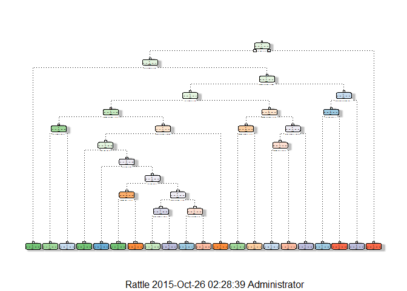

```r
modelFit1 <- rpart(classe ~ ., data=data.train.new, method="class")
fancyRpartPlot(modelFit1)
```

```r
pred1 <- predict(modelFit1, data.valid.new, type = "class")
confusionMatrix(pred1, data.valid.new$classe)
```

```
## Confusion Matrix and Statistics
##
##           Reference
## Prediction    A    B    C    D    E
##          A 1498  196   69  106   25
##          B   42  669   85   86   92
##          C   43  136  739  129  131
##          D   33   85   98  553   44
##          E   58   53   35   90  790
##
## Overall Statistics
##
##                Accuracy : 0.722
##                  95% CI : (0.7104, 0.7334)
##     No Information Rate : 0.2845
##     P-Value [Acc > NIR] : < 2.2e-16
##
##                   Kappa : 0.6467
##  Mcnemar's Test P-Value : < 2.2e-16
##
## Statistics by Class:
##
##                      Class: A Class: B Class: C Class: D Class: E
## Sensitivity            0.8949   0.5874   0.7203  0.57365   0.7301
## Specificity            0.9060   0.9357   0.9097  0.94717   0.9509
## Pos Pred Value         0.7909   0.6869   0.6273  0.68020   0.7700
## Neg Pred Value         0.9559   0.9043   0.9390  0.91897   0.9399
## Prevalence             0.2845   0.1935   0.1743  0.16381   0.1839
## Detection Rate         0.2545   0.1137   0.1256  0.09397   0.1342
## Detection Prevalence   0.3218   0.1655   0.2002  0.13815   0.1743
## Balanced Accuracy      0.9004   0.7615   0.8150  0.76041   0.8405
```

### Random Forest Model

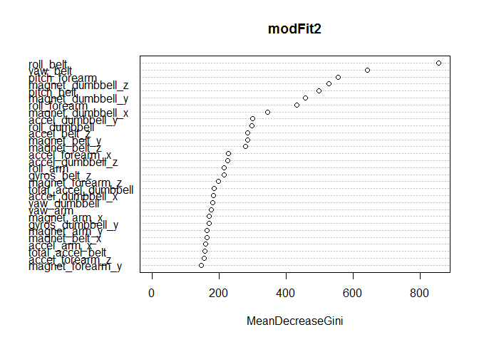

```r
set.seed(11111)
modFit2 <- randomForest(classe ~. , data=data.train.new, na.action = na.roughfix);
varImpPlot(modFit2)
```

```r
pred2 <- predict(modFit2, newdata = data.valid.new)
confusionMatrix(pred2, data.valid.new$classe)
```

```
## Confusion Matrix and Statistics
##
##           Reference
## Prediction    A    B    C    D    E
##          A 1673   11    0    0    0
##          B    1 1125   10    0    0
##          C    0    3 1014   13    0
##          D    0    0    2  951    5
##          E    0    0    0    0 1077
##
## Overall Statistics
##
##                Accuracy : 0.9924
##                  95% CI : (0.9898, 0.9944)
##     No Information Rate : 0.2845
##     P-Value [Acc > NIR] : < 2.2e-16
##
##                   Kappa : 0.9903
##  Mcnemar's Test P-Value : NA
##
## Statistics by Class:
##
##                      Class: A Class: B Class: C Class: D Class: E
## Sensitivity            0.9994   0.9877   0.9883   0.9865   0.9954
## Specificity            0.9974   0.9977   0.9967   0.9986   1.0000
## Pos Pred Value         0.9935   0.9903   0.9845   0.9927   1.0000
## Neg Pred Value         0.9998   0.9971   0.9975   0.9974   0.9990
## Prevalence             0.2845   0.1935   0.1743   0.1638   0.1839
## Detection Rate         0.2843   0.1912   0.1723   0.1616   0.1830
## Detection Prevalence   0.2862   0.1930   0.1750   0.1628   0.1830
## Balanced Accuracy      0.9984   0.9927   0.9925   0.9925   0.9977
```

As we see, this yields a model that is roughly 99.24% predictive with a 95% confidence interval between 98.98% and 99.44%. This is the best choice. The out of sample error on this model is 1-0.9924=0.0076.

## Prediction Assignment Submission

```r
answers <- predict(modFit2, newdata=data.testcase)
answers
```

```
##  1  2  3  4  5  6  7  8  9 10 11 12 13 14 15 16 17 18 19 20
##  B  A  B  A  A  E  D  B  A  A  B  C  B  A  E  E  A  B  B  B
## Levels: A B C D E
```

```r
pml_write_files = function(x){
  n = length(x)
  for(i in 1:n){
    filename = paste0("problem_id_",i,".txt")
    write.table(x[i],file=filename,quote=FALSE,row.names=FALSE,col.names=FALSE)
  }
}

pml_write_files(answers)
```

Predictions project submitted and 20 of 20 are correct.

## Conclusions and Observtions

The random forest appraoch with cross validation proved to perform very well for predicting activities from accelerometers measurements.